# Introduction to R

## What is R?

[figure not shown]

## What is R?

- A calculator:

```r
> 2+2
```

```
[1] 4
```

## What is R?

- A calculator
- A coding language:

```r
> var <- c(1,2,3,4,5,6)
> length(var)
```

```
[1] 6
```

## What is R?

- A calculator
- A coding language
- A statistics and graphical environment:

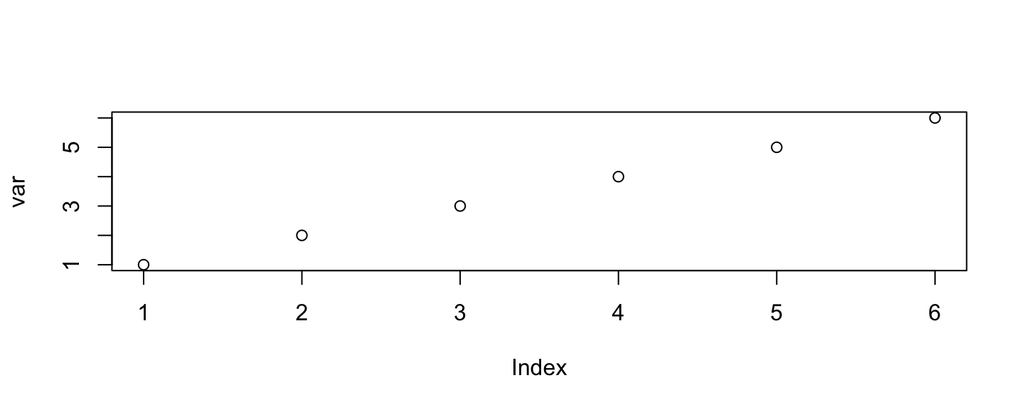

```r
> plot(var)
```

## RStudio

- Just like excel, or SPSS, or atom
- Integrated platform for writing and running R code
- Also a text editor, latex integration, version control, notebook, etc
- Has scripts (top left) and console (bottom left) - try to use scripts for saveable and reproducible code
- I even wrote this powerpoint in RStudio!!!

## Types of data

- Characters or strings
- Numbers or vectors or doubles
- Matrix or data frame

```r
> typeof(var)
```

```
[1] "double"
```

## Types of Data

```r
> var <- as.character(var)
> typeof(var)
```

```
[1] "character"
```

```r
> var
```

```
[1] "1" "2" "3" "4" "5" "6"
```

## Messing with data

```r
> var[4]
```

```
[1] "4"
```

```r
> y <- var[2:4]
> y
```

```
[1] "2" "3" "4"
```

## Packages etc

- Important thing about R is that everything can be googled
- Lots of libraries that mean you can do anything under the sun
- Most packages are on Github so you can even see how they are made!
- There are packages already for *most* things you want to do

## Some Rules

- Data needs to be *tidy*. This means:
  - Each row is an *observation*
  - Each variable is a *column*
  - Data should be in a *single dataset*

## How to R

- We assign variables with <- (or =)…

```r
> x <- 5
> x
```

```
[1] 5
```

```r
> x < 2
```

```
[1] FALSE
```

```r
> x == 5
```

```
[1] TRUE
```

## How to R

```r
> y <- 1:10
> y/x
```

```
 [1] 0.2 0.4 0.6 0.8 1.0 1.2 1.4 1.6 1.8 2.0
```

```r
> y*x
```

```
 [1]  5 10 15 20 25 30 35 40 45 50
```

```r
> y^x
```

```
 [1]      1     32    243   1024   3125   7776  16807  32768  59049 100000
```

```r
> #comments
```

## Messy Data

```r
> level <- c('Undergrad', 'Graduate')
> males <- c(7,2)
> females <- c(1,5)
> lab <- data.frame(level,males,females)
```

## Messy data

Lab Members

| level | males | females |
| --- | --- | --- |
| Undergrad | 7 | 1 |
| Graduate | 2 | 5 |

- How many variables do we actually have here???

## Tidy data

```r
> library(dplyr)
> library(tidyr)
> library(readr)
> lab2 <- pivot_longer(lab,
+                      cols = c(males, females),
+                      names_to = 'gender',
+                      values_to = 'number')
```

## Tidy data

Lab Members

| level | gender | number |
| --- | --- | --- |
| Undergrad | males | 7 |
| Undergrad | females | 1 |
| Graduate | males | 2 |
| Graduate | females | 5 |

## Tidy data

Lab Members

| level | gender | number |
| --- | --- | --- |
| Undergrad | males | 7 |
| Undergrad | females | 1 |
| Graduate | males | 2 |
| Graduate | females | 5 |

- Always aim for this - most R functions require it!

## Putting it back

- Sometime we do want a wide format for our own summaries etc
- Can still use pivot

```r
> lab_short <- pivot_wider(lab2,
+                          names_from = gender,
+                          values_from = number)
```

## Let’s look

Lab Members

| level | males | females |
| --- | --- | --- |
| Undergrad | 7 | 1 |
| Graduate | 2 | 5 |

## Chocolate survey

- Time for some “real” data
- I took a survey of prop of people in each research group who like each chocolate
- We need to open the file and get it out and take a look

## Chocolate survey

```r
> choc <- read_csv('choccies.csv')
```

[output not shown]

```r
> View(choc)
```

| Group | boost | bounty | lion | mars | snickers | wispa | yorkie |
| --- | --- | --- | --- | --- | --- | --- | --- |
| Cognitive | 0.2 | 0.70 | 0.40 | 0.80 | 0.10 | 0.62 | 0.28 |
| DevSci | 1.0 | 0.40 | 0.60 | 0.69 | 0.32 | 0.70 | 0.00 |
| QSP | 0.6 | 0.28 | 0.25 | 0.32 | 0.60 | 0.54 | 0.12 |

## What can we do with this?

```r
> summary(choc)
```

```
    Group               boost         bounty          lion
 Length:3           Min.   :0.2   Min.   :0.28   Min.   :0.2500
 Class :character   1st Qu.:0.4   1st Qu.:0.34   1st Qu.:0.3250
 Mode  :character   Median :0.6   Median :0.40   Median :0.4000
                    Mean   :0.6   Mean   :0.46   Mean   :0.4167
                    3rd Qu.:0.8   3rd Qu.:0.55   3rd Qu.:0.5000
                    Max.   :1.0   Max.   :0.70   Max.   :0.6000
      mars           snickers        wispa          yorkie
 Min.   :0.3200   Min.   :0.10   Min.   :0.54   Min.   :0.0000
 1st Qu.:0.5050   1st Qu.:0.21   1st Qu.:0.58   1st Qu.:0.0600
 Median :0.6900   Median :0.32   Median :0.62   Median :0.1200
 Mean   :0.6033   Mean   :0.34   Mean   :0.62   Mean   :0.1333
 3rd Qu.:0.7450   3rd Qu.:0.46   3rd Qu.:0.66   3rd Qu.:0.2000
 Max.   :0.8000   Max.   :0.60   Max.   :0.70   Max.   :0.2800
```

## What can we do with this?

- What if we are only interested in 2 choccies?

```r
> ctwo <- select(choc, boost, bounty)
```

| boost | bounty |
| --- | --- |
| 0.2 | 0.70 |
| 1.0 | 0.40 |
| 0.6 | 0.28 |

## What can we do with this?

- Whooops! We left out our groups variable!
- We can indicate a range with :

```r
> ctwo <- select(choc, Group:bounty)
```

| Group | boost | bounty |
| --- | --- | --- |
| Cognitive | 0.2 | 0.70 |
| DevSci | 1.0 | 0.40 |
| QSP | 0.6 | 0.28 |

## What can we do with this?

- Suppose we only want some rows
- Perhaps we (me) hypothesize that the only groups worth considering are those that rate Boost bars

```r
> cfil <- filter(choc, boost >= .5)
```

| Group | boost | bounty | lion | mars | snickers | wispa | yorkie |
| --- | --- | --- | --- | --- | --- | --- | --- |
| DevSci | 1.0 | 0.40 | 0.60 | 0.69 | 0.32 | 0.70 | 0.00 |
| QSP | 0.6 | 0.28 | 0.25 | 0.32 | 0.60 | 0.54 | 0.12 |

## What (else) can we do with this?

- OK, but maybe we don;t want to base everything on one type of choccy
- So we need to arrange it to see views all different choccies, arranged by boost

```r
> carr <- arrange(choc, desc(boost))
```

| Group | boost | bounty | lion | mars | snickers | wispa | yorkie |
| --- | --- | --- | --- | --- | --- | --- | --- |
| DevSci | 1.0 | 0.40 | 0.60 | 0.69 | 0.32 | 0.70 | 0.00 |
| QSP | 0.6 | 0.28 | 0.25 | 0.32 | 0.60 | 0.54 | 0.12 |
| Cognitive | 0.2 | 0.70 | 0.40 | 0.80 | 0.10 | 0.62 | 0.28 |

## Adding columns

- Lion is pretty important to us as well
- We need to add a column that will give us a better understanding

```r
> cmut <- mutate(choc,
+                weighting = (boost + lion)/2)
> cmut <- arrange(cmut, desc(boost))
```

| Group | boost | bounty | lion | mars | snickers | wispa | yorkie | weighting |
| --- | --- | --- | --- | --- | --- | --- | --- | --- |
| DevSci | 1.0 | 0.40 | 0.60 | 0.69 | 0.32 | 0.70 | 0.00 | 0.800 |
| QSP | 0.6 | 0.28 | 0.25 | 0.32 | 0.60 | 0.54 | 0.12 | 0.425 |
| Cognitive | 0.2 | 0.70 | 0.40 | 0.80 | 0.10 | 0.62 | 0.28 | 0.300 |

## Piping

- What we just did works, but isn’t very elegant…
- Rather than going step by step, it’s better to put it all together
- The operator %>% does this
- Any function with a f(x,y) argument can be written x %>% f(y)

## Piping

```r
> cmut <- choc %>%
+   mutate(weighting = (boost + lion)/2) %>%
+   arrange(desc(boost))
```

| Group | boost | bounty | lion | mars | snickers | wispa | yorkie | weighting |
| --- | --- | --- | --- | --- | --- | --- | --- | --- |
| DevSci | 1.0 | 0.40 | 0.60 | 0.69 | 0.32 | 0.70 | 0.00 | 0.800 |
| QSP | 0.6 | 0.28 | 0.25 | 0.32 | 0.60 | 0.54 | 0.12 | 0.425 |
| Cognitive | 0.2 | 0.70 | 0.40 | 0.80 | 0.10 | 0.62 | 0.28 | 0.300 |

## A note

```r
> cfil <- choc[choc$boost >= 0.5]
```

- Play with some of the options!

## Back to choccies

- So we can do cool stuff with the choccies data, but it’s not *tidy*
- What should it look like?
- Can you make it look like that???